# Practical Machine Learning- Course Project

Yash Deshpande

22 April 2018

## Introduction

Using devices such as Jawbone Up, Nike FuelBand, and Fitbit it is now possible to collect a large amount of data about personal activity relatively inexpensively. These type of devices are part of the quantified self movement - a group of enthusiasts who take measurements about themselves regularly to improve their health, to find patterns in their behavior, or because they are tech geeks. One thing that people regularly do is quantify how much of a particular activity they do, but they rarely quantify how well they do it. In this project, our goal will be to use data from accelerometers on the belt, forearm, arm, and dumbell of 6 participants. They were asked to perform barbell lifts correctly and incorrectly in 5 different ways. More information is available from the website here: http://groupware.les.inf.puc-rio.br/har (see the section on the Weight Lifting Exercise Dataset).

## Data Loading, Exploratory Analyses, and Cleaning

Let’s first load the required packages and datasets, and look at a summary of the data. A summary of all the variables measured can be found in the appendix under Ap. 1.

```r
library(caret)
library(rattle)
```

```r
library(ggplot2)
library(rpart)
library(rpart.plot)
library(randomForest)
library(knitr)
library(corrplot)
library(parallel)
library(doParallel)
cluster <- makeCluster(detectCores()-1)
registerDoParallel(cluster)

URLTrain <- "https://d396qusza40orc.cloudfront.net/predmachlearn/pml-training.csv"
URLTest <- "https://d396qusza40orc.cloudfront.net/predmachlearn/pml-testing.csv"

PMLTest <- read.csv(url(URLTest))
PMLTrain <- read.csv(url(URLTrain))

dim(PMLTrain)
```

```
## [1] 19622   160
```

```r
dim(PMLTest)
```

```
## [1]  20 160
```

We can see that the data shows 160 observed variables- 19622 training observations and 20 testing observations.

We first partition the training dataset provided into two sets, so that we have a validation set and can estimate the out-of-sample error more accurately.

```r
inTrain <- createDataPartition(PMLTrain$classe,p=0.7,list=FALSE)

PMLTrain_train <- PMLTrain[inTrain,]
PMLTrain_test <- PMLTrain[-inTrain,]

NrZeroVar <- nearZeroVar(PMLTrain_train)
PMLTrain_train  <- PMLTrain_train[,-NrZeroVar]
PMLTrain_test <- PMLTrain_test[,-NrZeroVar]

NAVar <- sapply(PMLTrain_train,function(x) mean(is.na(x))) > 0.95
PMLTrain_train <- PMLTrain_train[,NAVar==FALSE]
PMLTrain_test <- PMLTrain_test[,NAVar==FALSE]

PMLTrain_train <- PMLTrain_train[,-(1:5)]
PMLTrain_test <- PMLTrain_test[,-(1:5)]

dim(PMLTrain_train)
```

```
## [1] 13737    54
```

```r
dim(PMLTrain_test)
```

```
## [1] 5885   54
```

## Building a Prediction Model

### Model 1: Decision Tree

For our first model, we consider a simple decision tree. Before going ahead, please refer to Ap. 2 in the Appendix for a correlation plot of the entire dataset.

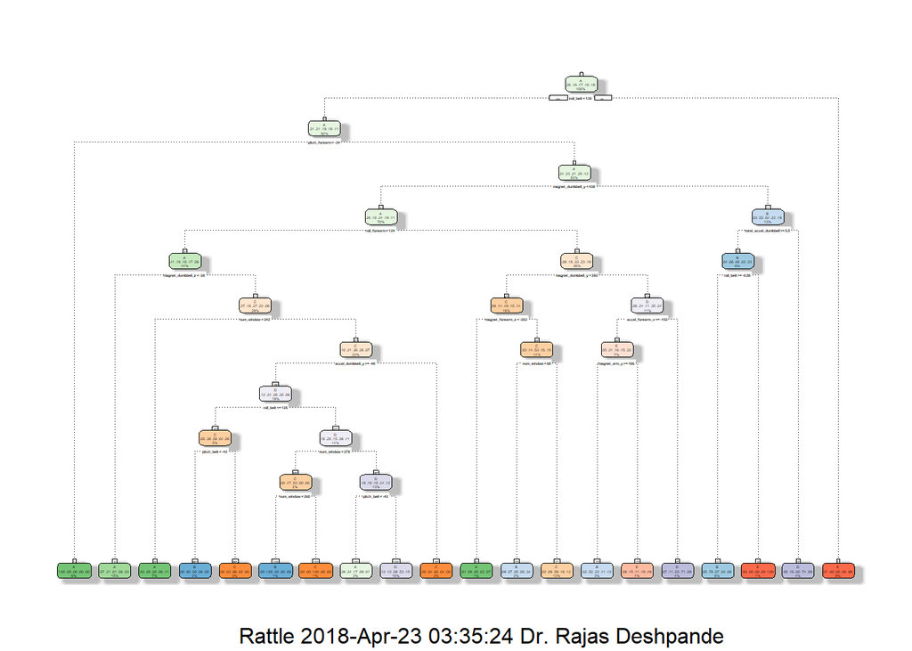

```r
set.seed(1109)
DecisionTreeModel <- rpart(classe~., method="class", data=PMLTrain_train)
fancyRpartPlot(DecisionTreeModel)
```

Now, we use the testing subset of the training dataset created earlier in order to test our model.

```r
pred_DT <- predict(DecisionTreeModel, newdata = PMLTrain_test, type="class")
DTConfusionMatrix <- confusionMatrix(pred_DT, PMLTrain_test$classe)
DTConfusionMatrix
```

```
## Confusion Matrix and Statistics
##
##           Reference
## Prediction    A    B    C    D    E
##          A 1487  249   51  108   75
##          B   48  627   72   32  114
##          C   25   66  820  140   78
##          D   94  158   55  637  126
##          E   20   39   28   47  689
##
## Overall Statistics
##
##                Accuracy : 0.7239
##                  95% CI : (0.7123, 0.7353)
##     No Information Rate : 0.2845
##     P-Value [Acc > NIR] : < 2.2e-16
##
##                   Kappa : 0.6489
##  Mcnemar's Test P-Value : < 2.2e-16
##
## Statistics by Class:
##
##                      Class: A Class: B Class: C Class: D Class: E
## Sensitivity            0.8883   0.5505   0.7992   0.6608   0.6368
## Specificity            0.8853   0.9440   0.9364   0.9120   0.9721
## Pos Pred Value         0.7548   0.7021   0.7263   0.5953   0.8372
## Neg Pred Value         0.9522   0.8974   0.9567   0.9321   0.9224
## Prevalence             0.2845   0.1935   0.1743   0.1638   0.1839
## Detection Rate         0.2527   0.1065   0.1393   0.1082   0.1171
## Detection Prevalence   0.3347   0.1517   0.1918   0.1818   0.1398
## Balanced Accuracy      0.8868   0.7472   0.8678   0.7864   0.8044
```

The decision tree method offers us ~72% prediction accuracy. We visualise the predictions from this method below:

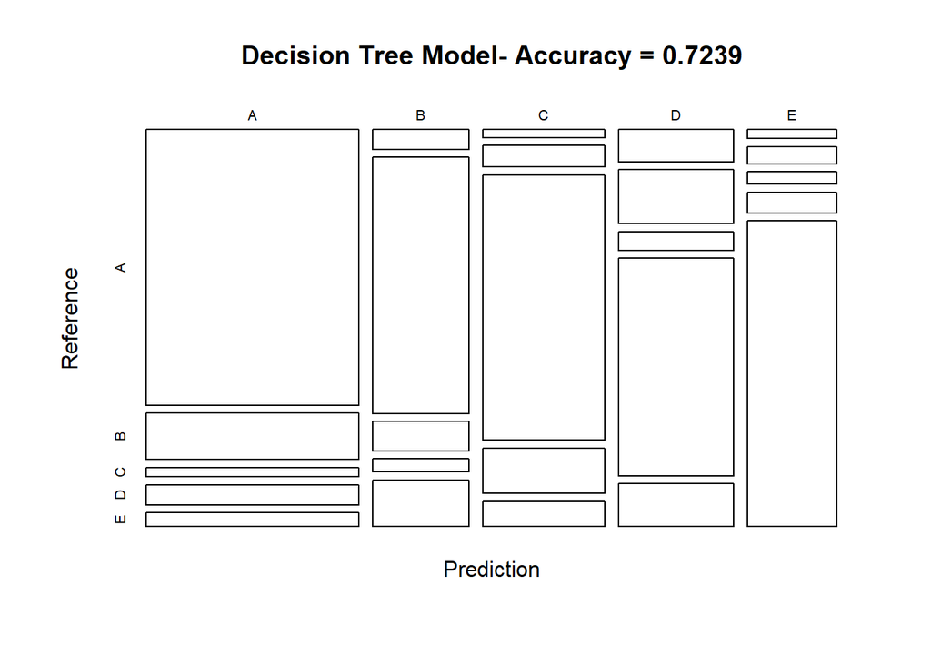

```r
plot(DTConfusionMatrix$table,col=DTConfusionMatrix$byClass, main=paste("Decision Tree Model- Accuracy =", round(DTConfusionMatrix$overall['Accuracy'],4)))
```

### Model 2: Random Forest

For our second model, we consider a random forest.

```r
set.seed(1109)
RFControl <- trainControl(method="cv", number=3, verboseIter = FALSE, allowParallel = TRUE)
RandomForestModel <- train(classe~., method="rf", data=PMLTrain_train, trControl = RFControl)
RandomForestModel$finalModel
```

```
##
## Call:
##  randomForest(x = x, y = y, mtry = param$mtry)
##                Type of random forest: classification
##                      Number of trees: 500
## No. of variables tried at each split: 27
##
##         OOB estimate of  error rate: 0.28%
## Confusion matrix:
##      A    B    C    D    E  class.error
## A 3904    1    0    0    1 0.0005120328
## B    7 2646    4    1    0 0.0045146727
## C    0    8 2387    1    0 0.0037562604
## D    0    0    8 2243    1 0.0039964476
## E    0    1    0    6 2518 0.0027722772
```

Now, we use the testing subset of the training dataset created earlier in order to test our model.

```r
pred_RF <- predict(RandomForestModel, newdata = PMLTrain_test)
RFConfusionMatrix <- confusionMatrix(pred_RF, PMLTrain_test$classe)
RFConfusionMatrix
```

```
## Confusion Matrix and Statistics
##
##           Reference
## Prediction    A    B    C    D    E
##          A 1674    7    0    0    0
##          B    0 1132    4    0    0
##          C    0    0 1022    5    0
##          D    0    0    0  959    3
##          E    0    0    0    0 1079
##
## Overall Statistics
##
##                Accuracy : 0.9968
##                  95% CI : (0.995, 0.9981)
##     No Information Rate : 0.2845
##     P-Value [Acc > NIR] : < 2.2e-16
##
##                   Kappa : 0.9959
##  Mcnemar's Test P-Value : NA
##
## Statistics by Class:
##
##                      Class: A Class: B Class: C Class: D Class: E
## Sensitivity            1.0000   0.9939   0.9961   0.9948   0.9972
## Specificity            0.9983   0.9992   0.9990   0.9994   1.0000
## Pos Pred Value         0.9958   0.9965   0.9951   0.9969   1.0000
## Neg Pred Value         1.0000   0.9985   0.9992   0.9990   0.9994
## Prevalence             0.2845   0.1935   0.1743   0.1638   0.1839
## Detection Rate         0.2845   0.1924   0.1737   0.1630   0.1833
## Detection Prevalence   0.2856   0.1930   0.1745   0.1635   0.1833
## Balanced Accuracy      0.9992   0.9965   0.9975   0.9971   0.9986
```

The random forest method offers us ~99.6% prediction accuracy. We visualise the predictions from this method below:

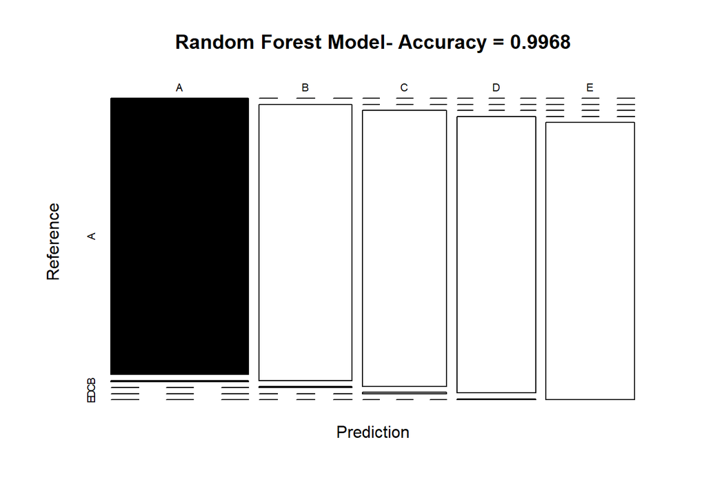

```r
plot(RFConfusionMatrix$table,col=RFConfusionMatrix$byClass, main=paste("Random Forest Model- Accuracy =", round(RFConfusionMatrix$overall['Accuracy'],4)))
```

### Model 3: Generalized Boosted Model (GBM)

For our third model, we consider a GBM.

```r
set.seed(1109)
GBMControl <- trainControl(method="repeatedcv", number=5, repeats=1, allowParallel = TRUE)
GBMModel <- train(classe~., method="gbm", data=PMLTrain_train, trControl=GBMControl, verbose=FALSE)
GBMModel$finalModel
```

```
## A gradient boosted model with multinomial loss function.
## 150 iterations were performed.
## There were 53 predictors of which 40 had non-zero influence.
```

```r
stopCluster(cluster)
```

Now, we use the testing subset of the training dataset created earlier in order to test our model.

```r
pred_GBM <- predict(GBMModel, newdata = PMLTrain_test)
GBMConfusionMatrix <- confusionMatrix(pred_GBM, PMLTrain_test$classe)
GBMConfusionMatrix
```

```
## Confusion Matrix and Statistics
##
##           Reference
## Prediction    A    B    C    D    E
##          A 1669   16    0    0    0
##          B    4 1118   12    5   10
##          C    0    5 1013   15    3
##          D    1    0    0  944   11
##          E    0    0    1    0 1058
##
## Overall Statistics
##
##                Accuracy : 0.9859
##                  95% CI : (0.9825, 0.9888)
##     No Information Rate : 0.2845
##     P-Value [Acc > NIR] : < 2.2e-16
##
##                   Kappa : 0.9822
##  Mcnemar's Test P-Value : NA
##
## Statistics by Class:
##
##                      Class: A Class: B Class: C Class: D Class: E
## Sensitivity            0.9970   0.9816   0.9873   0.9793   0.9778
## Specificity            0.9962   0.9935   0.9953   0.9976   0.9998
## Pos Pred Value         0.9905   0.9730   0.9778   0.9874   0.9991
## Neg Pred Value         0.9988   0.9956   0.9973   0.9959   0.9950
## Prevalence             0.2845   0.1935   0.1743   0.1638   0.1839
## Detection Rate         0.2836   0.1900   0.1721   0.1604   0.1798
## Detection Prevalence   0.2863   0.1952   0.1760   0.1624   0.1799
## Balanced Accuracy      0.9966   0.9875   0.9913   0.9884   0.9888
```

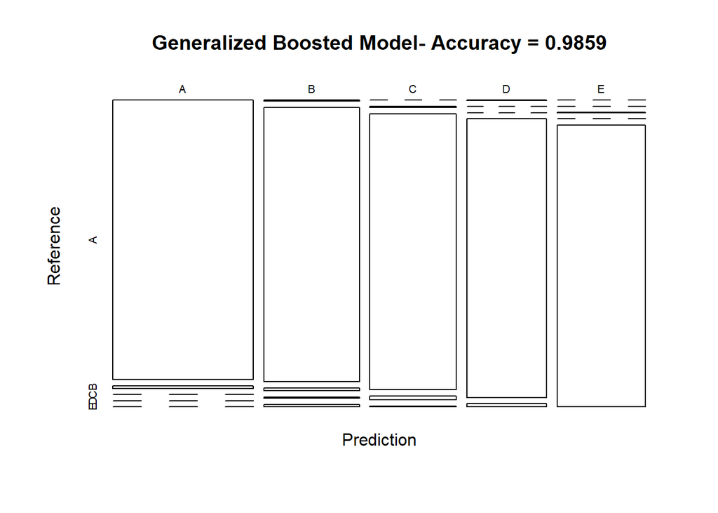

```r
plot(GBMConfusionMatrix$table,col=GBMConfusionMatrix$byClass, main=paste("Generalized Boosted Model- Accuracy =", round(GBMConfusionMatrix$overall['Accuracy'],4)))
```

## Conclusion

Since the random forest model offers the highest accuracy, ~99,6%, this model will be chosen as the final model. This model will also be applied to the testing dataset provided. From testing on the validation data we created, we can also approximate the out-of-sample error to be 0.32%.

```r
FinalPred_RF <- predict(RandomForestModel, newdata = PMLTest)
FinalPred_RF
```

```
##  [1] B A B A A E D B A A B C B A E E A B B B
## Levels: A B C D E
```

## Appendix

### Ap. 1- Summary of the training dataset

```r
str(PMLTrain)
```

```
## 'data.frame':    19622 obs. of  160 variables:
##  $ X                       : int  1 2 3 4 5 6 7 8 9 10 ...
##  $ user_name               : Factor w/ 6 levels "adelmo","carlitos",..: 2 2 2 2 2 2 2 2 2 2 ...
##  $ raw_timestamp_part_1    : int  1323084231 1323084231 1323084231 1323084232 1323084232 1323084232 1323084232 1323084232 1323084232 1323084232 ...
##  $ raw_timestamp_part_2    : int  788290 808298 820366 120339 196328 304277 368296 440390 484323 484434 ...
##  $ cvtd_timestamp          : Factor w/ 20 levels "02/12/2011 13:32",..: 9 9 9 9 9 9 9 9 9 9 ...
##  $ new_window              : Factor w/ 2 levels "no","yes": 1 1 1 1 1 1 1 1 1 1 ...
##  $ num_window              : int  11 11 11 12 12 12 12 12 12 12 ...
##  $ roll_belt               : num  1.41 1.41 1.42 1.48 1.48 1.45 1.42 1.42 1.43 1.45 ...
##  $ pitch_belt              : num  8.07 8.07 8.07 8.05 8.07 8.06 8.09 8.13 8.16 8.17 ...
##  $ yaw_belt                : num  -94.4 -94.4 -94.4 -94.4 -94.4 -94.4 -94.4 -94.4 -94.4 -94.4 ...
##  $ total_accel_belt        : int  3 3 3 3 3 3 3 3 3 3 ...
##  $ kurtosis_roll_belt      : Factor w/ 397 levels "","-0.016850",..: 1 1 1 1 1 1 1 1 1 1 ...
##  $ kurtosis_picth_belt     : Factor w/ 317 levels "","-0.021887",..: 1 1 1 1 1 1 1 1 1 1 ...
##  $ kurtosis_yaw_belt       : Factor w/ 2 levels "","#DIV/0!": 1 1 1 1 1 1 1 1 1 1 ...
```

[output cut: 86 more lines]

### Ap. 2- Correlation between Variables

In the plot below, highly correlated variables are shown in darker colours.

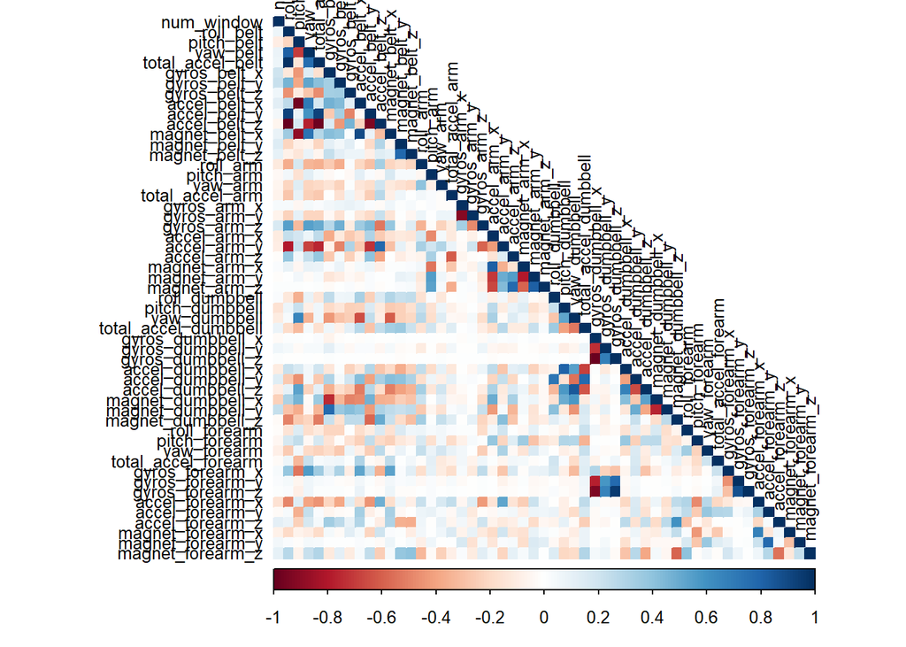

```r
correlationMatrix <- cor(PMLTrain_train[,-54])
corrplot(correlationMatrix,method="color",type="lower",tl.cex=0.8,tl.col=rgb(0,0,0))
```